# Предсказываем преступность в Чикаго на основе данных о погоде

Алина Бахитова

## Введение и данные

Изначально я вдохновилась исследованием моей одногруппницы - Арины Макковеевой. Она изучала связь между погодой и решениями судей. Было показано, что дождь и непогода связаны с более тяжелыми наказаниями для преступников.

После чего мне показалась интересной здача -- выяснить, можно ли предсказать уровень преступности на основе данных о погоде в этом месте.

Для этого я взяла две доступные базы по Чикаго:

1. Преступность в Чикаго за 2012-2017гг. по данным полиции (Chicago Police Department's CLEAR). В базе содержатся данные о дате, типе преступления, месте совершения, было ли это бытовое преступление и был ли совершен арест https://www.kaggle.com/currie32/crimes-in-chicago#Chicago_Crimes_2012_to_2017.csv
2. Погода в Чикаго до 2015г. с сайта метеорологической компании Weather Underground https://github.com/zonination/weather-us

При объединении двух баз остались только данные с 2012 по 2015г.

1. Дополнительно использовала данные о праздниках в США в качестве контроля: https://gist.github.com/shivaas/4758439

### Загрузка и чистка данных

```python
import pandas as pd
import numpy as np
import calendar
import datetime as dt
import matplotlib
import matplotlib.pyplot as plt
import seaborn as sns
import scipy
```

```python
holidays = pd.read_csv('holidays.csv')
weather = pd.read_csv("chicago.csv", ";")
crime = pd.read_csv("~/Chicago_Crimes_2012_to_2017.csv")
```

```python
crime2 = crime[['Date', 'Primary Type']].copy()
crime2.rename(columns = {'Date': 'date',
            'Primary Type': 'primary_type'}, inplace = True)
crime2.head()
```

```python
#преобразуем колонку с датой в нужный формат
crime2['date'] = pd.to_datetime(crime2['date']).dt.normalize()
#достаем нужные переменные -- сезон, дни недели,
#преобразуем температуру градусов по Фарингейту в Цельсия?
weather = weather[['Date', 'PrecipitationIn', "CloudCover",'Events','season', 'Mean.TemperatureF', 'MeanDew.PointF']].copy()
weather.rename(columns={'Date': 'date',
                      'PrecipitationIn': 'precipitation_in',
                       'CloudCover': 'cloud_cover',
                       'Events': 'events',
                       'Mean.TemperatureF': 'temperature',
                       'MeanDew.PointF': 'dew_point'}, inplace=True)
weather.head()
```

```python
weather['date'] = pd.to_datetime(weather['date']).dt.normalize()
weather['wday'] = weather['date'].dt.day_name()

weather.temperature = (weather.temperature -32)* 5/9
weather.dew_point = (weather.dew_point -32)* 5/9
#преобразуем колонку с погодными условиями в факторы
#преобразуем колонку с погодными условиями в факторы
weather['events'] = weather['events'].fillna('No')
weather['snow'] = weather.events.str.contains("Snow")*1
weather['fog'] = weather.events.str.contains("Fog")*1
weather['rain'] = weather.events.str.contains("Snow")*1
weather['no'] = weather.events.str.contains("No")*1
weather['thunderstorm'] = weather.events.str.contains("thunderstorm")*1
```

Немного почистили таблицы, теперь можно их объединять. По итогам получился 1461 день за 2012-2015гг., для которых есть информация о преступности и погоде.

## Разведывательный анализ данных

Для начала посмотрим на самые частовстречаемые преступления в Чикаго. В целом за этот период было совершено более 1млн. преступлений.

```python
holidays = pd.read_csv('holidays.csv')
holidays['date'] = pd.to_datetime(holidays['date']).dt.normalize()
holidays.head()
```

```python
holidays = holidays[['date']]
holidays['holiday'] = [1]*90
df = pd.merge(weather, holidays, on='date', how = "outer")
df = pd.merge(crime2, df, on="date", how = 'outer')

df['holiday'] = df['holiday'].fillna(0)
df = df[(df['date'] >= '2012-01-01') & (df['date'] < '2016-01-01')]

#итоговый датафрейм
df.head()
```

```python
df['primary_type'].value_counts().nlargest(6)
df = df[df['primary_type'] == 'THEFT']
df  = df.drop(['primary_type'], axis = 1)
df.head()
```

```python
def missing_values_table(df):
        mis_val = df.isnull().sum()
        mis_val_percent = 100 * df.isnull().sum() / len(df)
        mis_val_table = pd.concat([mis_val, mis_val_percent], axis=1)
        mis_val_table_ren_columns = mis_val_table.rename(
        columns = {0 : 'Missing Values', 1 : '% of Total Values'})
        mis_val_table_ren_columns = mis_val_table_ren_columns[
            mis_val_table_ren_columns.iloc[:,1] != 0].sort_values(
        '% of Total Values', ascending=False).round(1)
        print ("Your selected dataframe has " + str(df.shape[1]) + " columns.\n"
            "There are " + str(mis_val_table_ren_columns.shape[0]) +
              " columns that have missing values.")
        return mis_val_table_ren_columns
```

```python
missing_values_table(df)
```

```
Your selected dataframe has 15 columns.
There are 0 columns that have missing values.
```

|  | Missing Values | % of Total Values |
| --- | --- | --- |

На первых местах среди преступлений -- воровство (THEFT) и нанесение побоев (BATTERY). За ними, с большим отрывом следуют нанесение ущерба (CRIMINAL DAMAGE) и распространение или употребление наркотиков (NARCOTICS).

Для простоты дальнейшего анализа я оставила только один тип преступлений -- воровство. В данных осталось 265тыс. наблюдений.

Посмотрим, как распространены преступления по времени:

```python
x  = df['date'].value_counts(sort = False)
x = x.sort_index(ascending=True)
```

```python
plt.plot(x.index, x.values,
         linestyle='--', linewidth=.3, alpha=0.6)
plt.xticks(rotation=90)
plt.tick_params(axis='both', which='both',length=0)
plt.title('Распределение количества преступлений c 2012 по 2015 гг.', fontsize=12)
plt.show()
```

[output not shown]

На графике мы можем видеть сезонность - в летние периоды уровень воровства сильно возрастает, в сравнении с зимами.

Мы посмотрели на общий тренд преступности, но в какие же дни все-таки чаще совершаются преступления? Изначально я предполагала, что это будут как раз праздники.

```python
df['date'].value_counts().nlargest(15)
```

[output not shown]

Однако, если посмотреть на топ дней, то сверху будут первые дни месяцев за 2012 и 2013гг. Возможно, это ошибка в данных и на эти даты скидывались нераскрытые преступления, например.

Теперь попробуем подтвердить теорию о праздниках. Действительно ли в них чаще совершаются преступления.

```python
x = df.groupby(['date','holiday']).size().reset_index(name='count')#.unstack('holiday')
sns.boxplot(x='holiday', y='count',  data=x, palette='PRGn', width=0.6)
#"Количество преступлений в праздники (1) и обычные дни (0)"

# удаление первых чисел каждого месяца не поменяло картинку, а только убрало немного выбросов
```

```python
scipy.stats.shapiro(x['count'])

group1 = x['holiday'] == 0
group1 = x[group1]['count']
group2 = x['holiday'] == 1
group2 = x[group2]['count']
scipy.stats.ranksums(group1, group2)
```

```python
x['count'].groupby(x['holiday']).median()
```

Исключением правда является Новый Год, в который происходит больше всего криминальной активности. Что же, похоже получилось наоборот! Не в праздничные дни совершается больше преступлений в среднем, чем в праздники (Мed1 = 180, Med2 = 157, W = 3.980, p<.001). Возможно тут еще дело в количестве -- официальных праздников всего 90.

В чем еще может быть дело, если не в праздниках? Возможно это дни недели. Посмотрим на распределение:

```python
x= df.groupby(['date','wday']).size().reset_index(name='count')#.unstack('holiday')
sns.boxplot(x='wday', y='count',  data=x, palette='PRGn', width=0.6)
#"Количество преступлений по дням недели"
```

[output not shown]

Видим, что из распределения выделяются два дня: пятница (преступлений больше обычного) и воскресенье (преступлений меньше обычного). Для дальшейшего анализа можно было бы объединить остальные дни в одну категорию.

Изначальная задача была проверить, как погода и погодные условия связаны с уровнем преступности, что мы сейчас и посмотрим. За непогоду примем дождя и снега - объединим их в одну категорию, чтобы немного выравнять выборки. Предположение, что в непогоду совершается меньше преступлений.

```python
df['snow_rain'] = np.where((df['snow'] == 1) | (df['rain'] == 1), 1, 0)
x = df.groupby(['date','snow_rain']).size().reset_index(name='count')
```

```python
scipy.stats.shapiro(x['count'])
# Returns: 1) The test statistic, 2) p-value
```

```python
sns.boxplot(x='snow_rain', y='count', data=x, palette='PRGn', width=0.6)
```

```python
x.groupby(['snow_rain'])['count'].median()
```

```python
snow_rain_count = x[x.snow_rain == 1]['count']
no_snow_rain_count = x[x.snow_rain == 0]['count']
```

```python
# Compute the Wilcoxon rank-sum statistic for two samples.
scipy.stats.ranksums(x=snow_rain_count, y=no_snow_rain_count)
```

## Предсказываем преступность: дерево решений

Теперь перейдем к основной части -- попытке предсказать уровень преступности. Здесь переменную из численной -- количество преступлений типа воровство в конкретный день, преобразовала в бинарную: 0-уровень преступности выше или ниже среднего по сезону (лето, зима...) 1-уровень преступности выше среднего по сезону Преобразование в бинарный формат было мотивировано тем, что классификаторы работали в среднем лучше. А со средним хотелось сделать поправку на сезон, потому что летом в принципе больше преступлений совершается, чем, например, зимой, а нужно выяснить, как это работает и для других времен года тоже. В дополнение, это выравнивает количество наблюдений в предсказываемых классах.

```python
x = df.groupby(['date', 'season', 'cloud_cover', 'wday', 'temperature', 'snow_rain', 'holiday']).size().reset_index(name='count')
x.sort_values(by = 'count', ascending = False).head(10)
```

|  | date | season | cloud_cover | wday | temperature | snow_rain | holiday | count |
| --- | --- | --- | --- | --- | --- | --- | --- | --- |
| 0 | 2012-01-01 | Winter | 6.0 | Sunday | 2.777778 | 1 | 0.0 | 334 |
| 152 | 2012-06-01 | Spring | 7.0 | Friday | 13.888889 | 0 | 0.0 | 313 |
| 213 | 2012-08-01 | Summer | 2.0 | Wednesday | 26.666667 | 0 | 0.0 | 292 |
| 274 | 2012-10-01 | Autumn | 8.0 | Monday | 14.444444 | 0 | 0.0 | 290 |
| 547 | 2013-07-01 | Summer | 5.0 | Monday | 20.000000 | 0 | 0.0 | 286 |
| 182 | 2012-07-01 | Summer | 4.0 | Sunday | 25.555556 | 0 | 0.0 | 280 |
| 244 | 2012-09-01 | Summer | 8.0 | Saturday | 24.444444 | 0 | 0.0 | 279 |
| 180 | 2012-06-29 | Summer | 6.0 | Friday | 26.111111 | 0 | 0.0 | 276 |
| 227 | 2012-08-15 | Summer | 4.0 | Wednesday | 25.000000 | 0 | 0.0 | 273 |
| 568 | 2013-07-22 | Summer | 5.0 | Monday | 27.222222 | 0 | 0.0 | 272 |

```python
rows_to_remove = x.sort_values(by = 'count', ascending = False).head(7).index.values
rows_to_remove
#удаление этих 7 подозрительных дат, в которые совершается больше всего преступление и они все -- первые дни месяцев
y = x.drop(rows_to_remove, 0)

x['count_seasonal'] = x['count']>x.groupby('season')['count'].transform('median')*1
season = pd.get_dummies(x.season)
x = x.join(season)
wday = pd.get_dummies(x.wday)
x = x.join(wday)
#добавила еще переменную про предыдущий день -- было ли тогда совершено больше преступлений, чем в среднем.
```

```python
x['count_seasonal'] = x['count_seasonal']*1
x['lag_count'] = x['count_seasonal'].shift()
x = x[['count_seasonal', 'cloud_cover', 'temperature', 'snow_rain', 'holiday', 'Autumn', 'Summer', 'Winter', "Spring", "Friday", 'Sunday', 'lag_count']]
x = x.drop(0, 0)#уберем NA
x.head()
```

|  | count_seasonal | cloud_cover | temperature | snow_rain | holiday | Autumn | Summer | Winter | Spring | Friday | Sunday | lag_count |
| --- | --- | --- | --- | --- | --- | --- | --- | --- | --- | --- | --- | --- |
| 1 | 0 | 7.0 | -5.000000 | 1 | 1.0 | 0 | 0 | 1 | 0 | 0 | 0 | 1.0 |
| 2 | 1 | 4.0 | -7.222222 | 0 | 0.0 | 0 | 0 | 1 | 0 | 0 | 0 | 0.0 |
| 3 | 1 | 4.0 | 1.111111 | 0 | 0.0 | 0 | 0 | 1 | 0 | 0 | 0 | 1.0 |
| 4 | 1 | 4.0 | 3.333333 | 0 | 0.0 | 0 | 0 | 1 | 0 | 0 | 0 | 1.0 |
| 5 | 1 | 7.0 | 8.888889 | 0 | 0.0 | 0 | 0 | 1 | 0 | 1 | 0 | 1.0 |

```python
#x.to_csv("data_x.csv")
```

```python
#x = pd.read_csv("data_x.csv", ",")
#x = x.drop("Unnamed: 0",1)
#x.head()
```

[output not shown]

```python
#видим, что классы представлены примерно одинаково
x.groupby(['count_seasonal']).size()
```

```
count_seasonal
0    744
1    716
dtype: int64
```

```python
from random import seed
seed(13)
train, test = np.split(x.sample(frac=1), [int(.8*len(x))])
y_train = train['count_seasonal']
x_train = train.drop(['count_seasonal'], axis=1)
y_test = test['count_seasonal']
x_test = test.drop(['count_seasonal'], axis=1)
```

```python
import sklearn
from sklearn import tree
from sklearn.model_selection import cross_val_score
from sklearn import metrics
from IPython.display import Image
```

```python
tree_model = tree.DecisionTreeClassifier(max_depth=3)
tree_model = tree_model.fit(x_train, y_train)
tree_model.score(x_train, y_train)
#получис точность модели
```

```
0.761986301369863
```

```python
predicted = pd.DataFrame(tree_model.predict(x_test))
probs = pd.DataFrame(tree_model.predict_proba(x_test))

#разные метрики
tree_accuracy = metrics.accuracy_score(y_test, predicted)
tree_roc_auc = metrics.roc_auc_score(y_test, probs[1])
tree_confus_matrix = metrics.confusion_matrix(y_test, predicted)
tree_classification_report = metrics.classification_report(y_test, predicted)
tree_precision = metrics.precision_score(y_test, predicted, pos_label=1)
tree_recall = metrics.recall_score(y_test, predicted, pos_label=1)
tree_f1 = metrics.f1_score(y_test, predicted, pos_label=1)

# оценка модели с кросс-валидацией
tree_cv_scores = cross_val_score(tree.DecisionTreeClassifier(max_depth=3), x_test, y_test, scoring='precision', cv=10)
```

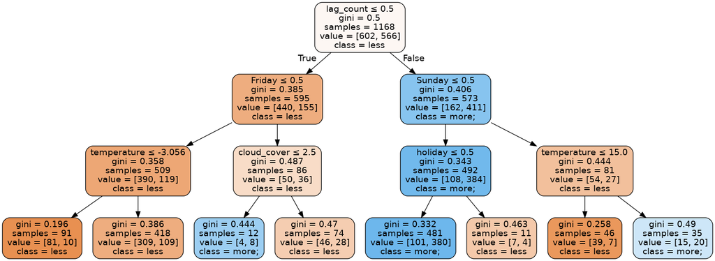

```python
# нарисуем финальную модель
from pydotplus import graph_from_dot_data

dot_data = tree.export_graphviz(tree_model, out_file=None,
                     feature_names=x_test.columns.tolist(),
                     class_names=['less', 'more;'],
                     filled=True, rounded=True,
                     special_characters=True)
graph = graph_from_dot_data(dot_data)
graph.write_png("decision_tree.png")
Image("decision_tree.png")
```

Что же можно понять по модели? Самым важным предиктором оказался день предшествующий предсказываемому, то есть если в предыдущий день не происходило ничего сверхнеобычного в уровне преступности, то и сегодня скорее всего ничего не будет (n=91+418+74). Исключение составляют те пятницы, в которые низкая облачность -- в такие дни уровень преступность выше (n=12).

# в отличие от такой же модели полученной в р, разделение в этой ветке заканчивалось. точность осталась такой же

Опять же на втором месте по важности, преступность связана с днями недели, а конкретно с воскресеньем. При условии, что в предущий день был повышен уровень преступности, то идет разделение по переменной воскресенье. Для жарких(?) воскресных дней, когда температура превышает 15градусов, преступность также будет высокой (n=35). Для холодных дней, наоборот преступность скорее всего будет низкая (n=46). Для остальных же дней становятся важными праздники -- в праздничные дни преступность будет ниже (n=11), чем в обычные (n=481), несмотря на то, что в предыдущий день было много воровства.

### Выводы:

Что узнали?

В чем прелесть этой модели, так это в том, что практически вся информация (кроме конечно преступности за предыдущий день) лежит в открытом доступе и не требуют особых усилий для сборов, поэтому ее легко воспроизвести и использовать для своих городов.